# Analysis of dry above-ground biomass

Author

Achyut Kumar Banerjee

Published

February 3, 2026

## About the variable

- All above-ground plant material of *Parthenium* within each quadrat was clipped at ground level. We utilized the destructive harvest method to ensure maximum accuracy.
- The samples were cleaned of debris and oven-dried at 72<sup>0</sup>C until a constant weight was reached.
- Dry weight was recorded, eliminating the variability caused by fluctuating water content in live plants, thus providing a true measure of carbon sequestration and resource allocation. The standardized area allows for the calculation of biomass per unit area.

We also recorded number of associated species in each quadrat (species richness). The number of associated species varies from 2 to 11. We estimated dry weight of all associated species individually. For comparative analysis, we used the sum of all species within a quadrat at a specific lake x habitat combination.

**Dry Above-Ground Biomass (AGB, hereafter)** serves as a critical indicator of invasion success. It is a physical manifestation of a plant’s ability to capture resources (light, water, and nutrients). Therefore, high biomass in *Parthenium* indicates high **resource use efficiency**. In addition, larger plants with higher biomass typically produce a greater number of seeds (often up to 25,000 seeds per plant for *Parthenium*). Therefore, AGB can be considered as a proxy for **propagule pressure**.

Comparing AGB across different habitats (e.g., roadside vs. natural areas vs. abandoned plots) reveals how environmental stressors or anthropogenic disturbances facilitate invasion. Roadsides often act as **invasion corridors** with higher nutrient runoff, leading to higher biomass compared to more stable abandoned plots.

## About the analysis

- Summary stattistics [mean AGB, standard deviation and standard error] - for Parthenium and other species Summary statistics
- Comparison of mean AGB (Parthenium and other species) between 4 water bodies and 3 habitats Comparison: One-way ANOVA:
- Comparison of mean AGB (Parthenium and other species) across 4 water bodies and 3 habitats (and their interactions) Comparison: Two-way ANOVA
- Comparison of mean AGB between Parthenium and other species (pulling all data together) Comparison: Paired t-test (All species)
- Comparison of mean AGB between Parthenium and other species across 4 water bodies and 3 habitats Comparison: Two-way ANOVA (All species)
- To check if Parthenium AGB is influenced by other species biomass or species richness Regression analysis
- Plot average and median AGB for Parthenium and other species separately and together Plotting

## Install and load packages

```r
library(tidyverse)
library(ggpubr)
library(rstatix)
library(datarium)
library(rstatix)
library(ARTool) # for 2-way ANOVA
library(car) # for the Levene test
library(FSA) # for posthoc test
library(ggplot2) # for plotting
library(Rmisc) # for summary statistics
library(wesanderson) # for plotting
library(dplyr)
```

## Set the working directory

```r
setwd("/Users/achyutkumarbanerjee/Library/CloudStorage/OneDrive-AzimPremjiFoundation/Student research/Parthenium summer/partheniumBhopal")
```

## Analysis

### Read data

```r
data<-read.csv("biomass_data.csv")
```

### Factorization

Coercing the 2 objects (Lake and Habitat) into factors. The factors will represent categorical data. Factors are useful for statistical modeling and plotting as they treat data as discrete categories rather than continuous numbers or simple characters.

```r
data$group1<-as.factor(data$Lake)
data$group2<-as.factor(data$Habitat)
```

Check the levels of the 2 categorical variables

```r
levels(data$group1)
```

```
[1] "Hathaikheda_Dam" "Kerwa_Dam"       "Lower_Lake"      "Upper_Lake"
```

```r
levels(data$group2)
```

```
[1] "Abandoned" "Natural"   "Roadside"
```

### Summary statistics

We will create 3 vectors to store the result - one for both the categorical variables together (Lake and Habitat) and two for them separately. For summary statistics, we will use the *summarySE* function of the `Rmisc` package. This function gives count, mean, standard deviation, standard error of the mean, and confidence interval (default 95%).

**Arguments**

- data: a data frame
- measurevar: the name of a column that contains the variable to be summarized
- groupvars: a vector containing names of columns that contain grouping variables

```r
parthenium <- summarySE(data, measurevar="Dry.weight", groupvars=c("group1","group2"))
parthenium
```

| group1 | group2 | N | Dry.weight | sd | se | ci |
| --- | --- | --- | --- | --- | --- | --- |
| Hathaikheda_Dam | Abandoned | 3 | 28.71733 | 8.850634 | 5.109916 | 21.986195 |
| Hathaikheda_Dam | Natural | 3 | 25.89033 | 3.596503 | 2.076442 | 8.934208 |
| Hathaikheda_Dam | Roadside | 3 | 38.08033 | 11.969384 | 6.910527 | 29.733599 |
| Kerwa_Dam | Abandoned | 3 | 32.76500 | 6.654752 | 3.842123 | 16.531319 |
| Kerwa_Dam | Natural | 2 | 37.17400 | 24.986325 | 17.668000 | 224.493225 |
| Kerwa_Dam | Roadside | 3 | 14.60967 | 8.368878 | 4.831774 | 20.789445 |
| Lower_Lake | Abandoned | 3 | 40.71067 | 7.374099 | 4.257438 | 18.318277 |
| Lower_Lake | Natural | 3 | 25.79967 | 5.891333 | 3.401363 | 14.634882 |
| Lower_Lake | Roadside | 3 | 53.45567 | 34.673473 | 20.018739 | 86.133683 |
| Upper_Lake | Abandoned | 3 | 62.36000 | 25.117406 | 14.501541 | 62.395097 |

[output cut: 2 more lines]

```r
others<-summarySE(data, measurevar="Dry.weight_O", groupvars=c("group1","group2"))
others
```

| group1 | group2 | N | Dry.weight_O | sd | se | ci |
| --- | --- | --- | --- | --- | --- | --- |
| Hathaikheda_Dam | Abandoned | 3 | 21.41927 | 2.151195 | 1.2419930 | 5.343864 |
| Hathaikheda_Dam | Natural | 3 | 20.47029 | 1.300659 | 0.7509356 | 3.231015 |
| Hathaikheda_Dam | Roadside | 3 | 24.71983 | 7.518613 | 4.3408734 | 18.677271 |
| Kerwa_Dam | Abandoned | 3 | 19.29924 | 1.360470 | 0.7854678 | 3.379595 |
| Kerwa_Dam | Natural | 2 | 20.78185 | 1.679025 | 1.1872500 | 15.085442 |
| Kerwa_Dam | Roadside | 3 | 24.13271 | 5.430606 | 3.1353617 | 13.490373 |
| Lower_Lake | Abandoned | 3 | 20.25866 | 4.327557 | 2.4985164 | 10.750248 |
| Lower_Lake | Natural | 3 | 16.82882 | 1.082045 | 0.6247192 | 2.687950 |
| Lower_Lake | Roadside | 3 | 19.65376 | 2.348928 | 1.3561542 | 5.835061 |
| Upper_Lake | Abandoned | 3 | 24.02839 | 2.372091 | 1.3695275 | 5.892601 |

[output cut: 2 more lines]

```r
parthenium1 <- summarySE(data, measurevar="Dry.weight", groupvars=c("group1"))
parthenium1
```

| group1 | N | Dry.weight | sd | se | ci |
| --- | --- | --- | --- | --- | --- |
| Hathaikheda_Dam | 9 | 30.89600 | 9.442744 | 3.147581 | 7.258335 |
| Kerwa_Dam | 8 | 27.05900 | 15.213826 | 5.378900 | 12.719077 |
| Lower_Lake | 9 | 39.98867 | 21.599471 | 7.199824 | 16.602823 |
| Upper_Lake | 9 | 66.17478 | 25.374220 | 8.458073 | 19.504352 |

```r
parthenium2 <- summarySE(data, measurevar="Dry.weight", groupvars=c("group2"))
parthenium2
```

| group2 | N | Dry.weight | sd | se | ci |
| --- | --- | --- | --- | --- | --- |
| Abandoned | 12 | 41.13825 | 18.19233 | 5.251673 | 11.558855 |
| Natural | 11 | 33.17536 | 13.12372 | 3.956951 | 8.816636 |
| Roadside | 12 | 49.28492 | 33.76811 | 9.748014 | 21.455235 |

```r
others1 <- summarySE(data, measurevar="Dry.weight_O", groupvars=c("group1"))
others1
```

| group1 | N | Dry.weight_O | sd | se | ci |
| --- | --- | --- | --- | --- | --- |
| Hathaikheda_Dam | 9 | 22.20313 | 4.409517 | 1.4698390 | 3.389455 |
| Kerwa_Dam | 8 | 21.48245 | 3.814566 | 1.3486527 | 3.189057 |
| Lower_Lake | 9 | 18.91374 | 2.977878 | 0.9926258 | 2.288999 |
| Upper_Lake | 9 | 26.96324 | 7.218284 | 2.4060948 | 5.548465 |

```r
others2 <- summarySE(data, measurevar="Dry.weight_O", groupvars=c("group2"))
others2
```

| group2 | N | Dry.weight_O | sd | se | ci |
| --- | --- | --- | --- | --- | --- |
| Abandoned | 12 | 21.25139 | 3.004165 | 0.8672277 | 1.908755 |
| Natural | 11 | 21.45290 | 6.497629 | 1.9591089 | 4.365167 |
| Roadside | 12 | 24.46517 | 6.401078 | 1.8478321 | 4.067051 |

### Checking assumptions

```r
data %>%
  group_by(group1) %>%
  shapiro_test(Dry.weight)
```

| group1 | variable | statistic | p |
| --- | --- | --- | --- |
| Hathaikheda_Dam | Dry.weight | 0.8229940 | 0.037245875 |
| Kerwa_Dam | Dry.weight | 0.9578544 | 0.789431026 |
| Lower_Lake | Dry.weight | 0.7389249 | 0.004032482 |
| Upper_Lake | Dry.weight | 0.9388443 | 0.569787281 |

```r
data %>%
  group_by(group2) %>%
  shapiro_test(Dry.weight)
```

| group2 | variable | statistic | p |
| --- | --- | --- | --- |
| Abandoned | Dry.weight | 0.8146353 | 0.01381005 |
| Natural | Dry.weight | 0.8440388 | 0.03567041 |
| Roadside | Dry.weight | 0.9131594 | 0.23415494 |

```r
data %>%
  group_by(group1) %>%
  shapiro_test(Dry.weight_O)
```

| group1 | variable | statistic | p |
| --- | --- | --- | --- |
| Hathaikheda_Dam | Dry.weight_O | 0.6826214 | 0.0008891644 |
| Kerwa_Dam | Dry.weight_O | 0.8559308 | 0.1093339303 |
| Lower_Lake | Dry.weight_O | 0.8732629 | 0.1332325982 |
| Upper_Lake | Dry.weight_O | 0.8299538 | 0.0446015515 |

```r
data %>%
  group_by(group2) %>%
  shapiro_test(Dry.weight_O)
```

| group2 | variable | statistic | p |
| --- | --- | --- | --- |
| Abandoned | Dry.weight_O | 0.9664913 | 0.8708063026 |
| Natural | Dry.weight_O | 0.6695021 | 0.0001904746 |
| Roadside | Dry.weight_O | 0.8986574 | 0.1524141701 |

Following the normality check, we evaluate the **homogeneity of variance** across groups using Levene’s Test. This step is critical for verifying the homoscedasticity assumption required for parametric tests like ANOVA. Levene’s test is more robust to departures from normality. A non-significant result ($p < 0.05$) indicates that the variances are approximately equal across groups. We are using the `car` package to do this analysis.

```r
leveneTest(Dry.weight ~ group1, data = data)
```

|  | Df | F value | Pr(>F) |
| --- | --- | --- | --- |
| group | 3 | 1.445726 | 0.2484546 |
|  | 31 | NA | NA |

```r
leveneTest(Dry.weight ~ group2, data = data)
```

|  | Df | F value | Pr(>F) |
| --- | --- | --- | --- |
| group | 2 | 4.172384 | 0.02453602 |
|  | 32 | NA | NA |

```r
leveneTest(Dry.weight_O ~ group1, data = data)
```

|  | Df | F value | Pr(>F) |
| --- | --- | --- | --- |
| group | 3 | 1.062304 | 0.379243 |
|  | 31 | NA | NA |

```r
leveneTest(Dry.weight_O ~ group2, data = data)
```

|  | Df | F value | Pr(>F) |
| --- | --- | --- | --- |
| group | 2 | 0.9307061 | 0.4046864 |
|  | 32 | NA | NA |

### Comparison: One-way ANOVA

A One-Way ANOVA is used to determine whether there are any statistically significant differences between the means of three or more independent (unrelated) groups based on one single factor.

- Independent variable (factor): 3 categories of habitats / 4 categories of lakes
- Dependent variable: Above-ground dry biomass

We will do 3 things here:

- Because the previous diagnostic checks (Shapiro-Wilk or Levene’s) indicated a violation of parametric assumptions, we employ the **Kruskal-Wallis test**. This is a non-parametric alternative to a one-way ANOVA that does not require the data to follow a normal distribution. Instead of comparing means, it transforms the data into ranks and tests whether the samples originate from the same distribution. A significant p-value (p<0.05) suggests that at least one group stochastically dominates another.
- When reporting a Kruskal-Wallis test, a p-value only tells you if groups differ, not how much they differ. To quantify the magnitude of the difference, we calculate the **Effect Size**. For non-parametric data, the most common metric is Eta-squared (η2).
- When the Kruskal-Wallis test yields a significant result, it indicates that at least one group differs from the others, but it does not specify which pairs are different. To pinpoint these differences, we conduct a Dunn’s Test, which is the standard non-parametric post-hoc procedure. We are using the `FSA` package to do this analysis.

**First, we will do it for Parthenium**

```r
# Group 1 (Lake)
kruskal.test(Dry.weight ~ group1, data = data)
```

```
    Kruskal-Wallis rank sum test

data:  Dry.weight by group1
Kruskal-Wallis chi-squared = 14.248, df = 3, p-value = 0.002587
```

```r
kruskal_effsize(Dry.weight ~ group1,data = data) # effect size estimation
```

|  | .y. | n | effsize | method | magnitude |
| --- | --- | --- | --- | --- | --- |
| 1 | Dry.weight | 35 | 0.3628307 | eta2[H] | large |

**Important**

Summary:

- The KW test showed significant difference in AGB of Parthenium across lakes.
- The effect size is large.

```r
dunnTest(Dry.weight~group1,data=data) #posthoc test
```

```
Dunn (1964) Kruskal-Wallis multiple comparison
```

```
  p-values adjusted with the Holm method.
```

```
                    Comparison          Z      P.unadj       P.adj
1  Hathaikheda_Dam - Kerwa_Dam  0.6722514 0.5014236945 0.501423694
2 Hathaikheda_Dam - Lower_Lake -0.7360699 0.4616881414 0.923376283
3       Kerwa_Dam - Lower_Lake -1.3863441 0.1656418648 0.496925594
4 Hathaikheda_Dam - Upper_Lake -2.9212775 0.0034859914 0.017429957
5       Kerwa_Dam - Upper_Lake -3.5063068 0.0004543711 0.002726227
6      Lower_Lake - Upper_Lake -2.1852076 0.0288736282 0.115494513
```

**Important**

Summary:

- The posthoc Dunn test revealed that Parthenium AGB in Upper Lake is significantly higher than that in Kerwa Dam and Hathaikheda Dam.

```r
# Group 2 (Habitat)
kruskal.test(Dry.weight ~ group2, data = data)
```

```
    Kruskal-Wallis rank sum test

data:  Dry.weight by group2
Kruskal-Wallis chi-squared = 1.5662, df = 2, p-value = 0.457
```

```r
kruskal_effsize(Dry.weight ~ group2,data = data) # effect size estimation
```

|  | .y. | n | effsize | method | magnitude |
| --- | --- | --- | --- | --- | --- |
| 1 | Dry.weight | 35 | -0.01355745 | eta2[H] | small |

**Important**

Summary:

- The KW test showed no significant difference in AGB of Parthenium across habitats. Therefore, no posthoc test is done.
- The effect size is small.

**Then, for other species**

```r
# Group 1 (Lake)
kruskal.test(Dry.weight_O ~ group1, data = data)
```

```
    Kruskal-Wallis rank sum test

data:  Dry.weight_O by group1
Kruskal-Wallis chi-squared = 12.699, df = 3, p-value = 0.005336
```

```r
kruskal_effsize(Dry.weight_O ~ group1,data = data) # effect size estimation
```

|  | .y. | n | effsize | method | magnitude |
| --- | --- | --- | --- | --- | --- |
| 1 | Dry.weight_O | 35 | 0.3128563 | eta2[H] | large |

**Important**

Summary:

- The KW test showed significant difference in AGB of other species across lakes.
- The effect size is large.

```r
dunnTest(Dry.weight_O~group1,data=data) #posthoc test
```

```
Dunn (1964) Kruskal-Wallis multiple comparison
```

```
  p-values adjusted with the Holm method.
```

```
                    Comparison          Z      P.unadj       P.adj
1  Hathaikheda_Dam - Kerwa_Dam  0.3821512 0.7023492288 0.702349229
2 Hathaikheda_Dam - Lower_Lake  1.9091814 0.0562386973 0.224954789
3       Kerwa_Dam - Lower_Lake  1.4700268 0.1415544917 0.283108983
4 Hathaikheda_Dam - Upper_Lake -1.6331552 0.1024363685 0.307309106
5       Kerwa_Dam - Upper_Lake -1.9665444 0.0492357576 0.246178788
6      Lower_Lake - Upper_Lake -3.5423365 0.0003965991 0.002379595
```

**Important**

Summary:

- The posthoc test revealed that AGB of other species is significantly higher in Upper lake than in Lower Lake.

```r
# Group 2 (Habitat)
kruskal.test(Dry.weight_O ~ group2, data = data)
```

```
    Kruskal-Wallis rank sum test

data:  Dry.weight_O by group2
Kruskal-Wallis chi-squared = 2.2623, df = 2, p-value = 0.3227
```

```r
kruskal_effsize(Dry.weight_O ~ group2,data = data) # effect size estimation
```

|  | .y. | n | effsize | method | magnitude |
| --- | --- | --- | --- | --- | --- |
| 1 | Dry.weight_O | 35 | 0.008195797 | eta2[H] | small |

**Important**

Summary:

- The KW test showed no significant difference in AGB of other species across habitats. Therefore, no posthoc test is done.
- The effect size is small.

### Comparison: Two-way ANOVA

A Two-Way ANOVA examines the effect of two independent variables on a dependent variable. It not only tells you if each factor is significant on its own (Main Effects) but also if the factors work together in a specific way (Interaction Effect).

- Independent variable (factor): 3 categories of habitats and 4 categories of lakes
- Dependent variable: Above-ground dry biomass

When analyzing the influence of two independent variables on a non-normally distributed dependent variable, traditional non-parametric tests like Kruskal-Wallis are insufficient because they cannot test for interactions. To address this, we use the Aligned Rank Transform (ART).

ART works by “aligning” the data for each effect (Main Effects and Interaction) before ranking them. This process isolates each specific effect, allowing us to apply standard ANOVA procedures to the ranked data. This provides a statistically sound method to determine if the effect of one factor depends on the level of another, even when parametric assumptions are violated.

To identify specific differences following a significant ART interaction, we conduct pairwise comparisons using the `art.con()` function. This method ensures that the comparisons are performed on the correctly aligned and ranked data for the effect of interest. We apply a p-value adjustment (e.g., Holm) to control for the family-wise error rate across multiple comparisons.We are using the `ARTool` package to do this analysis.

**First, we will do it for Parthenium**

```r
art_model <- art(Dry.weight ~ group1 * group2, data = data) # model building
anova_art <- anova(art_model) # conducting anova
print(anova_art) # print the results
```

```
Analysis of Variance of Aligned Rank Transformed Data

Table Type: Anova Table (Type III tests)
Model: No Repeated Measures (lm)
Response: art(Dry.weight)

                Df Df.res F value     Pr(>F)
1 group1         3     23 10.4292 0.00015849 ***
2 group2         2     23  3.0187 0.06852839   .
3 group1:group2  6     23  3.0259 0.02490477   *
---
Signif. codes:   0 '***' 0.001 '**' 0.01 '*' 0.05 '.' 0.1 ' ' 1
```

**Important**

Summary of two-way ANOVA:

- The ART analysis revealed significant effect of group 1 (Lake) and the interaction of group 1 and group 2 (Lake x Habitat) on the AGB of Parthenium.
- So, we will conduct the posthoc tests only for group 1 and group1:group2 interactions.

```r
# pairwise comparisons for one variable
marginal = art.con(art_model, "group1")
```

```
NOTE: Results may be misleading due to involvement in interactions
```

```r
print(marginal)
```

```
 contrast                     estimate   SE df t.ratio p.value
 Hathaikheda_Dam - Kerwa_Dam      2.33 3.90 23   0.598  0.9318
 Hathaikheda_Dam - Lower_Lake    -5.33 3.75 23  -1.422  0.4992
 Hathaikheda_Dam - Upper_Lake   -17.22 3.75 23  -4.591  0.0007
 Kerwa_Dam - Lower_Lake          -7.67 3.90 23  -1.963  0.2307
 Kerwa_Dam - Upper_Lake         -19.56 3.90 23  -5.008  0.0003
 Lower_Lake - Upper_Lake        -11.89 3.75 23  -3.169  0.0207

Results are averaged over the levels of: group2
P value adjustment: tukey method for comparing a family of 4 estimates
```

```r
# pairwise comparisons for interactions
marginal1 = art.con(art_model, "group1:group2", adjust="holm")
```

**Important**

**Then, for other species**

```r
art_model1 <- art(Dry.weight_O ~ group1 * group2, data = data) # model building
anova_art1 <- anova(art_model1) # conducting anova
print(anova_art1) # print the results
```

```
Analysis of Variance of Aligned Rank Transformed Data

Table Type: Anova Table (Type III tests)
Model: No Repeated Measures (lm)
Response: art(Dry.weight_O)

                Df Df.res F value   Pr(>F)
1 group1         3     23  3.8861 0.022035 *
2 group2         2     23  1.0988 0.350128
3 group1:group2  6     23  0.3948 0.874701
---
Signif. codes:   0 '***' 0.001 '**' 0.01 '*' 0.05 '.' 0.1 ' ' 1
```

**Important**

Summary of two-way ANOVA:

- The ART analysis revealed significant effect of group 1 (Lake) on the AGB of other species.
- So, we will conduct the posthoc tests only for group 1.

```r
# pairwise comparisons for one variable
marginal2 = art.con(art_model1, "group1")
```

```
NOTE: Results may be misleading due to involvement in interactions
```

```r
print(marginal2)
```

```
 contrast                     estimate   SE df t.ratio p.value
 Hathaikheda_Dam - Kerwa_Dam    0.0556 4.85 23   0.011  1.0000
 Hathaikheda_Dam - Lower_Lake   8.5556 4.66 23   1.836  0.2827
 Hathaikheda_Dam - Upper_Lake  -7.3333 4.66 23  -1.574  0.4125
 Kerwa_Dam - Lower_Lake         8.5000 4.85 23   1.753  0.3209
 Kerwa_Dam - Upper_Lake        -7.3889 4.85 23  -1.524  0.4404
 Lower_Lake - Upper_Lake      -15.8889 4.66 23  -3.410  0.0120

Results are averaged over the levels of: group2
P value adjustment: tukey method for comparing a family of 4 estimates
```

**Important**

Summary of pairwise interactions:

- The AGB of other species in Upper Lake is significantly higher than that in the Lower Lake, after adjusting for the effects of the habitats.
- This result is similar to what we observed in one-way ANOVA [Comparison: One-way ANOVA].

### Comparison: Paired t-test (All species)

Now we are interested to check whether the Parthenium biomass is significantly higher or lower than that of the other species. Because the previous diagnostic checks (Shapiro-Wilk or Levene’s) indicated a violation of parametric assumptions, we use the **Wilcoxon Signed-Rank Test**. This is a non-parametric alternative to a paired t-test that does not require the data to follow a normal distribution.

```r
wilcox.test(data$Dry.weight, data$Dry.weight_O, paired = TRUE)
```

```
    Wilcoxon signed rank exact test

data:  data$Dry.weight and data$Dry.weight_O
V = 590, p-value = 5.052e-07
alternative hypothesis: true location shift is not equal to 0
```

**Important**

Summary of the paired t-test (overall)

- The Wilcoxon Signed-Rank Test shows that AGB of Parthenium is significantly higher than other species.

### Comparison: Two-way ANOVA (All species)

Now we are interested to check whether the Parthenium biomass is significantly higher than that of the other species **across different lakes and habitats**. We will first use 2-way ANOVA to identify if the difference in AGB values between Parthenium and other species is due to lake, habitat, or both.

```r
# Calculate the difference to use as the dependent variable
data$Weight_Diff <- data$Dry.weight - data$Dry.weight_O

# Fit the ART model
art_model <- art(Weight_Diff ~ group1 * group2, data = data)

# Run the ANOVA on the aligned ranks
anova_art <- anova(art_model)
print(anova_art)
```

```
Analysis of Variance of Aligned Rank Transformed Data

Table Type: Anova Table (Type III tests)
Model: No Repeated Measures (lm)
Response: art(Weight_Diff)

                Df Df.res F value     Pr(>F)
1 group1         3     23  8.3178 0.00063154 ***
2 group2         2     23  1.8576 0.17871671
3 group1:group2  6     23  3.0581 0.02383002   *
---
Signif. codes:   0 '***' 0.001 '**' 0.01 '*' 0.05 '.' 0.1 ' ' 1
```

**Important**

Summary of the ART analysis

- The 2-way ANOVA showed that the difference in AGB values between Parthenium and other species is influenced by lake (group 1) and the interaction between lake and habitat.
- There is no effect of habitat on the AGB difference.

Therefore, the next step would be to identify the lakes where the AGB difference between Parthenium and other species is significant. For this, we will first **subset** data for each lake. Note that we are reporting median AGB, because our data is highly skewed and we are using non-parametric tests.

```r
# For Lower Lake
lower_lake_data  <- subset(data, Lake == "Lower_Lake")
lake_comparison <- lower_lake_data %>%
  summarise(
    Median_Parthenium = median(Dry.weight),
    Median_Others = median(Dry.weight_O),
    p_value = wilcox.test(Dry.weight, Dry.weight_O, paired = TRUE)$p.value,
    Median_Diff = median(Dry.weight - Dry.weight_O)
  )
print(lake_comparison)
```

```
  Median_Parthenium Median_Others    p_value Median_Diff
1             33.79       17.6184 0.00390625     14.8058
```

```r
# For Upper Lake
upper_lake_data  <- subset(data, Lake == "Upper_Lake")
lake_comparison <- upper_lake_data %>%
  summarise(
    Median_Parthenium = median(Dry.weight),
    Median_Others = median(Dry.weight_O),
    p_value = wilcox.test(Dry.weight, Dry.weight_O, paired = TRUE)$p.value,
    Median_Diff = median(Dry.weight - Dry.weight_O)
  )
print(lake_comparison)
```

```
  Median_Parthenium Median_Others    p_value Median_Diff
1            55.561      23.68233 0.00390625    33.71267
```

```r
# For Kerwa Dam
kerwa_dam_data   <- subset(data, Lake == "Kerwa_Dam")
lake_comparison <- kerwa_dam_data %>%
  summarise(
    Median_Parthenium = median(Dry.weight),
    Median_Others = median(Dry.weight_O),
    p_value = wilcox.test(Dry.weight, Dry.weight_O, paired = TRUE)$p.value,
    Median_Diff = median(Dry.weight - Dry.weight_O)
  )
print(lake_comparison)
```

```
  Median_Parthenium Median_Others  p_value Median_Diff
1            23.179      20.19605 0.546875     2.10845
```

```r
# For Hathaikheda Dam
hathaikheda_data <- subset(data, Lake == "Hathaikheda_Dam")
lake_comparison <- hathaikheda_data %>%
  summarise(
    Median_Parthenium = median(Dry.weight),
    Median_Others = median(Dry.weight_O),
    p_value = wilcox.test(Dry.weight, Dry.weight_O, paired = TRUE)$p.value,
    Median_Diff = median(Dry.weight - Dry.weight_O)
  )
print(lake_comparison)
```

```
  Median_Parthenium Median_Others    p_value Median_Diff
1             26.06      21.27325 0.00390625      6.1768
```

**Important**

Summary of the lake-wise paired t-test

- Parthenium AGB is significantly higher than other species AGB across all lakes, except for the Kerwa Dam.
- The highest difference between the median AGB of Parthenium and that of other species was observed in Upper Lake.

```r
# 1. Get the unique lakes and habitats
lakes <- unique(data$Lake)
habitats <- unique(data$Habitat)

# 3. Create an empty list to store the results of each loop
results_list <- list()

# 4. Start the nested loop
for (l in lakes) {
  for (h in habitats) {

    # Subset the data for the specific combination
    sub_data <- subset(data, Lake == l & Habitat == h)

    # Check if we have data for this combination
    if (nrow(sub_data) > 0) {

      # Run the Wilcoxon test
      # exact = FALSE handles ties; paired = TRUE is for your paired design
      test <- wilcox.test(sub_data$Dry.weight,
                          sub_data$Dry.weight_O,
                          paired = TRUE,
                          exact = FALSE)

      # Extract values and store them in a temporary data frame (one row)
      res_row <- data.frame(
        Lake = l,
        Habitat = h,
        N = nrow(sub_data),
        Median_Parthenium = median(sub_data$Dry.weight),
        Median_Others = median(sub_data$Dry.weight_O),
        W_Stat = test$statistic,
        P_Value = test$p.value,
        stringsAsFactors = FALSE
      )

      # Add this row to the list using a unique name
      results_list[[paste(l, h, sep = "_")]] <- res_row
    }
  }
}

# 5. Combine all the stored rows into one final summary table
summary_table <- do.call(rbind, results_list)

# 6. Reset the row names and display the result
rownames(summary_table) <- NULL
print(summary_table)
```

```
              Lake   Habitat N Median_Parthenium Median_Others W_Stat   P_Value
1       Lower_Lake  Roadside 3            36.362      19.11887      6 0.1814492
2       Lower_Lake Abandoned 3            39.875      19.02460      6 0.1814492
3       Lower_Lake   Natural 3            22.828      17.34960      6 0.1814492
4       Upper_Lake  Roadside 3            85.031      28.13057      6 0.1814492
5       Upper_Lake Abandoned 3            55.561      23.68233      6 0.1814492
6       Upper_Lake   Natural 3            49.089      22.85700      6 0.1814492
7        Kerwa_Dam  Roadside 3            17.363      25.30114      0 0.1814492
8        Kerwa_Dam Abandoned 3            36.090      18.95914      6 0.1814492
9        Kerwa_Dam   Natural 2            37.174      20.78185      2 1.0000000
10 Hathaikheda_Dam  Roadside 3            44.752      21.62750      6 0.1814492
11 Hathaikheda_Dam Abandoned 3            25.397      21.27325      6 0.1814492
12 Hathaikheda_Dam   Natural 3            26.060      19.88320      6 0.1814492
```

**Important**

Interpretation of the findings:

- In the **Kerwa_Dam - Roadside** row, we can see `Median_Others` is higher.
- In the **Upper_Lake - Roadside** row, we will see the largest gap between the two.

**W_Stat:** This tells us the sum of the ranks. For n=3, a W=6 (or W=0) means all three sites followed the same trend (e.g., the AGB of Parthenium was more than that of other species in all three sites).

### Regression analysis

To check if **Parthenium AGB** is influenced by **other species biomass** or **species richness**, we can use multiple regression and see how they work together as predictors.

```r
# Multiple Linear Regression
model <- lm(Dry.weight ~ Dry.weight_O + Species.richness, data = data)
summary(model)
```

```
Call:
lm(formula = Dry.weight ~ Dry.weight_O + Species.richness, data = data)

Residuals:
    Min      1Q  Median      3Q     Max
-32.135 -10.608  -5.617   8.510  60.427

Coefficients:
                 Estimate Std. Error t value Pr(>|t|)
(Intercept)       -5.7931    22.1471  -0.262    0.795
Dry.weight_O       1.6978     0.7476   2.271    0.030 *
Species.richness   1.7622     1.8170   0.970    0.339
---
Signif. codes:  0 '***' 0.001 '**' 0.01 '*' 0.05 '.' 0.1 ' ' 1

Residual standard error: 22.83 on 32 degrees of freedom
Multiple R-squared:   0.14, Adjusted R-squared:  0.08623
F-statistic: 2.604 on 2 and 32 DF,  p-value: 0.08957
```

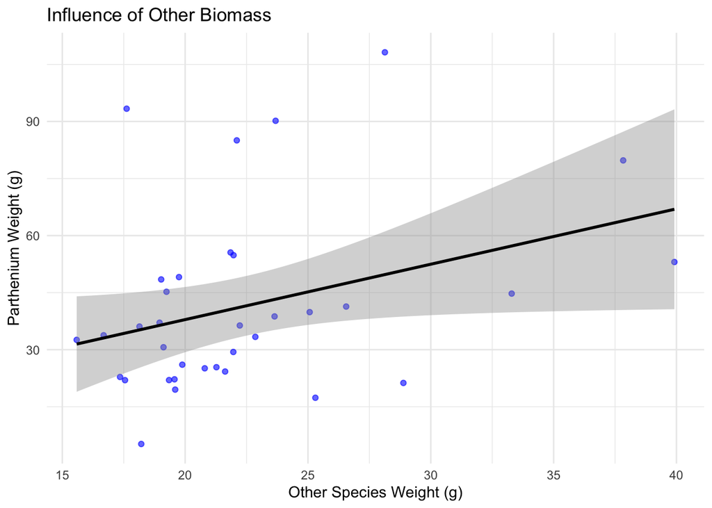

```r
# 4. Visualization (Scatter plots)
library(ggplot2)

p1 <- ggplot(data, aes(x = Dry.weight_O, y = Dry.weight)) +
  geom_point(color = "blue", alpha = 0.6) +
  geom_smooth(method = "lm", color = "black") +
  labs(title = "Influence of Other Biomass", x = "Other Species Weight (g)", y = "Parthenium Weight (g)") +
  theme_minimal()
p1
```

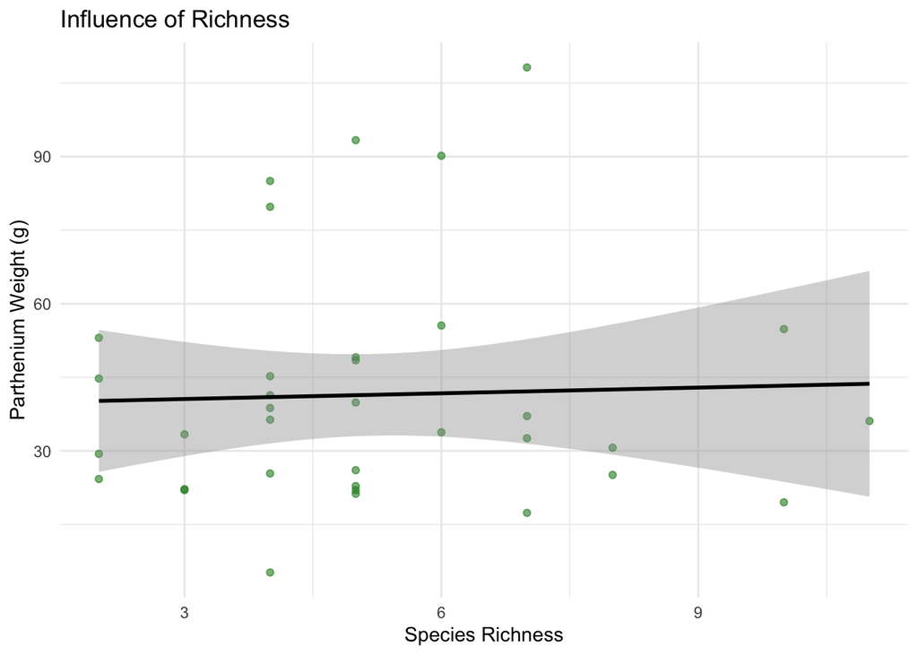

```r
p2 <- ggplot(data, aes(x = Species.richness, y = Dry.weight)) +
  geom_point(color = "forestgreen", alpha = 0.6) +
  geom_smooth(method = "lm", color = "black") +
  labs(title = "Influence of Richness", x = "Species Richness", y = "Parthenium Weight (g)") +
  theme_minimal()
p2
```

**Important**

Interpretation of the regression analysis

- While species richness had no discernible impact on *Parthenium* biomass (p>0.05), a significant positive relationship was found with the biomass of other species (Regression, p=0.03).
- This suggests that *Parthenium* does not currently face strong competitive exclusion from local biodiversity; instead, it thrives in the same high-productivity conditions that support other vegetation.

## Plotting

We are plotting the summarized data in the form of 2 grouped bar plots - one for Parthenium and one for the other species.

- x-axis: Lake (4 lakes) (group1).
- y-axis: Dry weight (gm) [AGB]
- For each lake, we will have 3 bars. Each bar will represent the AGB of *Parthenium* for one habitat (abandoned, natural and roadsides - group2). So, there will be a total of 12 bars (4 lakes x 3 habitats).
- We will add a title to the plot, write x and y axes labels, and add the SE bars to each bar.- We are using `ggplot2` package for plotting and `wesanderson` package for colouring the bars.

**For Parthenium**

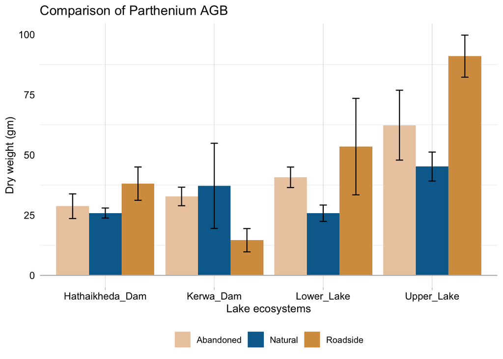

```r
p<-ggplot(parthenium, aes(fill=group2, y=Dry.weight, x=group1)) +
  geom_bar(position="dodge", stat="identity")+
  geom_errorbar(aes(ymin=Dry.weight-se, ymax=Dry.weight+se),
                width=.2,position = position_dodge(0.9))
p1<-p+labs(title="Comparison of Parthenium AGB", x="Lake ecosystems", y = "Dry weight (gm)")+
  theme_light() +
  scale_fill_manual(values = wes_palette(n=3, name="Darjeeling2"))+
  theme(legend.position="bottom")+
  geom_hline(yintercept=0,color="gray")
p2<-p1+theme(
  panel.grid.major.y = element_blank(),
  panel.border = element_blank(),
  axis.ticks.y = element_blank(),
  axis.text = element_text(size = 10,color = "black"),
  axis.title = element_text(size = 11),
  legend.title=element_blank()
)
p2
```

**For other species**

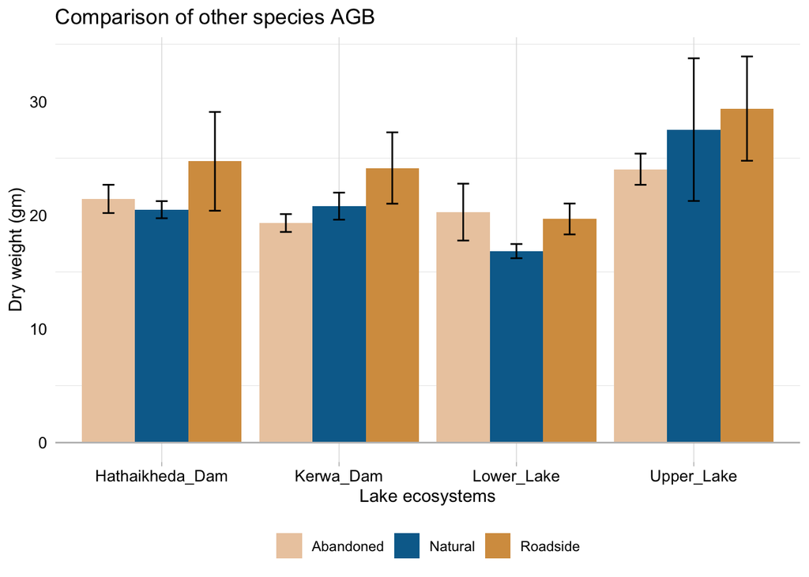

```r
p<-ggplot(others, aes(fill=group2, y=Dry.weight_O, x=group1)) +
  geom_bar(position="dodge", stat="identity")+
  geom_errorbar(aes(ymin=Dry.weight_O-se, ymax=Dry.weight_O+se),
                width=.2,position = position_dodge(0.9))
p1<-p+labs(title="Comparison of other species AGB", x="Lake ecosystems", y = "Dry weight (gm)")+
  theme_light() +
  scale_fill_manual(values = wes_palette(n=3, name="Darjeeling2"))+
  theme(legend.position="bottom")+
  geom_hline(yintercept=0,color="gray")
p2<-p1+theme(
  panel.grid.major.y = element_blank(),
  panel.border = element_blank(),
  axis.ticks.y = element_blank(),
  axis.text = element_text(size = 10,color = "black"),
  axis.title = element_text(size = 11),
  legend.title=element_blank()
)
p2
```

**Combined box plot**

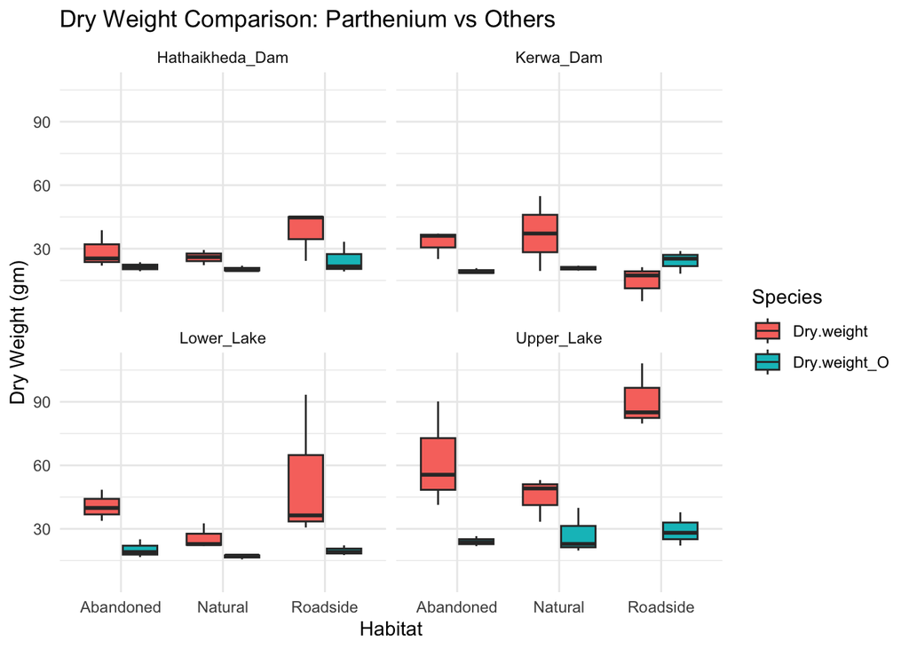

```r
# Reshape data for plotting
library(tidyr)
data_long <- data %>%
  pivot_longer(cols = c(Dry.weight, Dry.weight_O),
               names_to = "Species",
               values_to = "Weight")

# Create Boxplot
ggplot(data_long, aes(x = Habitat, y = Weight, fill = Species)) +
  geom_boxplot() +
  facet_wrap(~Lake) +
  labs(title = "Dry Weight Comparison: Parthenium vs Others",
       y = "Dry Weight (gm)",
       x = "Habitat") +
  theme_minimal()
```